# Time Series Analysis project - forecast three-month and ten-year treasury maturity rates with VAR

Lin Xinyang.Monica

2023-08-13

```r
r = getOption("repos")
r["CRAN"] = "http://cran.us.r-project.org"
options(repos = r)
```

## Packages

Let’s load packages we will need to use for analysis

```r
install.packages("xts")
install.packages("lmtest")
```

```r
install.packages("ggplot2")
install.packages("zoo")
install.packages("tidyverse")
install.packages("dplyr")
install.packages("vars")
install.packages("knitr")
install.packages("kableExtra")
library(xts)
library(lmtest)
library(ggplot2)
library(zoo)
library(tidyverse)
library(dplyr)
library(vars)
library(knitr)
library(kableExtra)
source(file="D://Desktop//testdf.R")
```

## Import and process data

We will import data used for analysis and coerce it into “xts” dataset indexed by date

```r
r3m_r10y<-read.csv(file="D://Desktop//mrates.csv")
head(r3m_r10y,10)
```

```
##          date  r3m r10y
## 1  1986-01-01 7.25 9.00
## 2  1986-02-03 7.21 9.02
## 3  1986-03-03 7.26 7.99
## 4  1986-04-01 6.58 7.37
## 5  1986-05-01 6.21 7.45
## 6  1986-06-02 6.43 8.32
## 7  1986-07-01 6.26 7.37
## 8  1986-08-01 6.00 7.34
## 9  1986-09-01 5.42 6.95
## 10 1986-10-01 5.39 7.41
```

```r
tail(r3m_r10y,10)
```

```
##           date  r3m r10y
## 402 2019-06-03 2.37 2.07
## 403 2019-07-01 2.13 2.03
## 404 2019-08-01 2.09 1.90
## 405 2019-09-02 1.99 1.50
## 406 2019-10-01 1.88 1.65
## 407 2019-11-01 1.59 1.73
## 408 2019-12-02 1.61 1.83
## 409 2020-01-01 1.58 1.92
## 410 2020-02-03 1.56 1.54
## 411 2020-03-02 1.46 1.10
```

```r
class(r3m_r10y)
```

```
## [1] "data.frame"
```

```r
r3m_r10y$date<-as.Date(x=r3m_r10y$date,format="%Y-%m-%d")
r3m_r10y<-xts(x=r3m_r10y[,-1],order.by =r3m_r10y$date)
```

Data visualization

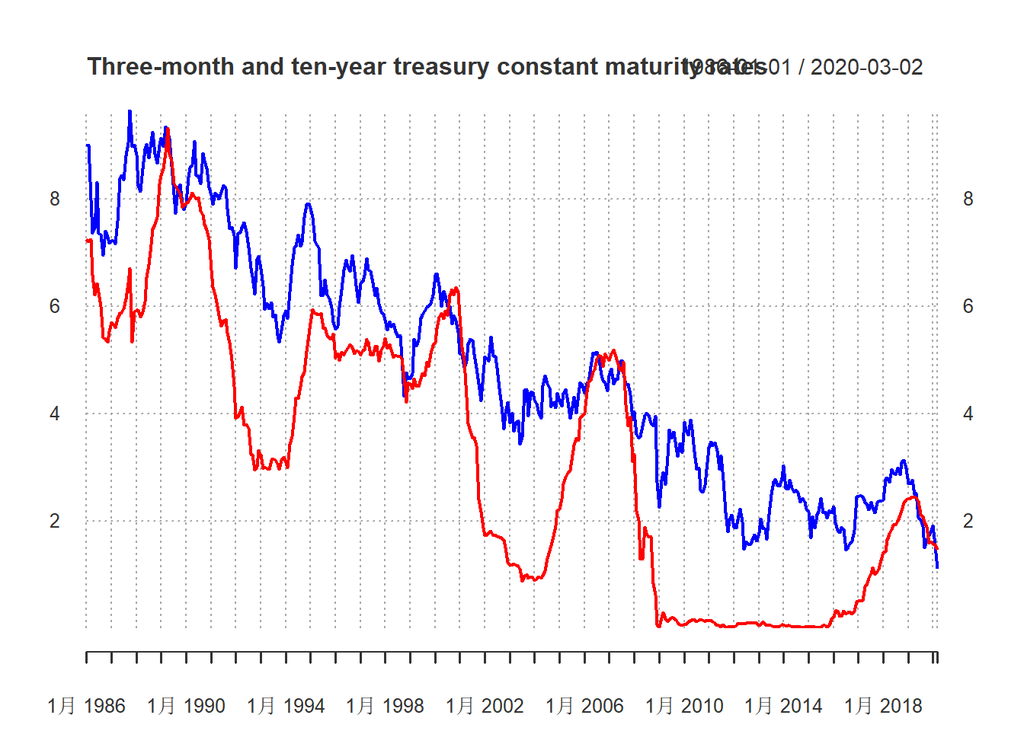

```r
plot(r3m_r10y[,1:2],
  type="l",
  col=c("red","blue"),
  major.ticks="years",
  grid.ticks.on="years",
  grid.ticks.lty=3,
  main="Three-month and ten-year treasury constant maturity rates"
)
```

They seem non-stationary and have a certain long-run relationship. But we need to perform formal tests to confirm this.

## Cointegration

Let’s check whether r3m and r10y are integrated of the same order

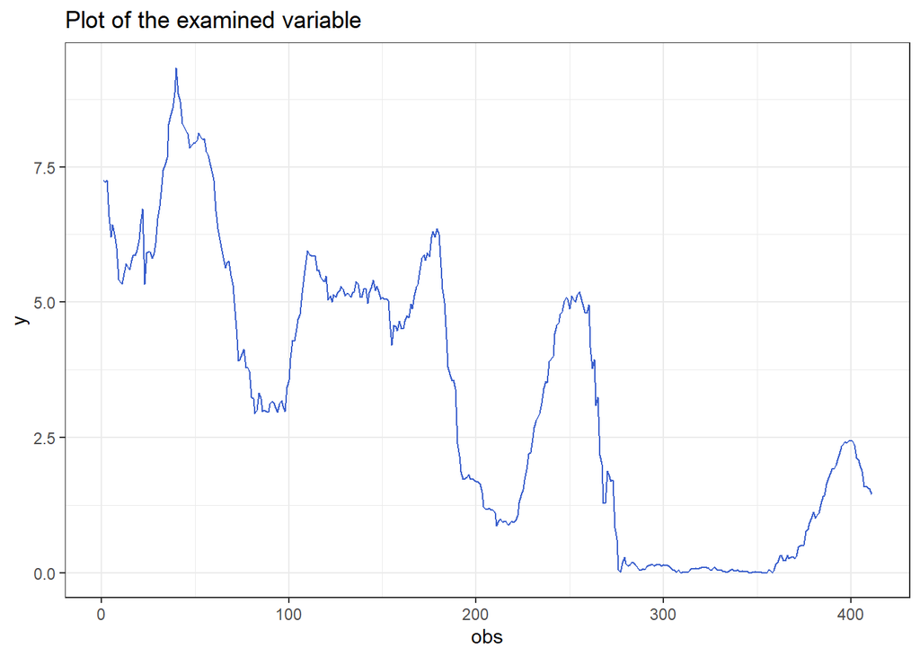

```
##   augmentations       adf     p_adf   bgodfrey         p_bg
## 1             0 -1.435437 0.5234236 15.9544675 6.488446e-05
## 2             1 -1.514603 0.4938782  0.8372772 3.601766e-01
## 3             2 -1.719090 0.4175629  0.3880262 5.333387e-01
## 4             3 -1.648023 0.4440854  0.1699445 6.801612e-01
```

```r
testdf(variable=r3m_r10y$r3m,max.augmentations = 3)
```

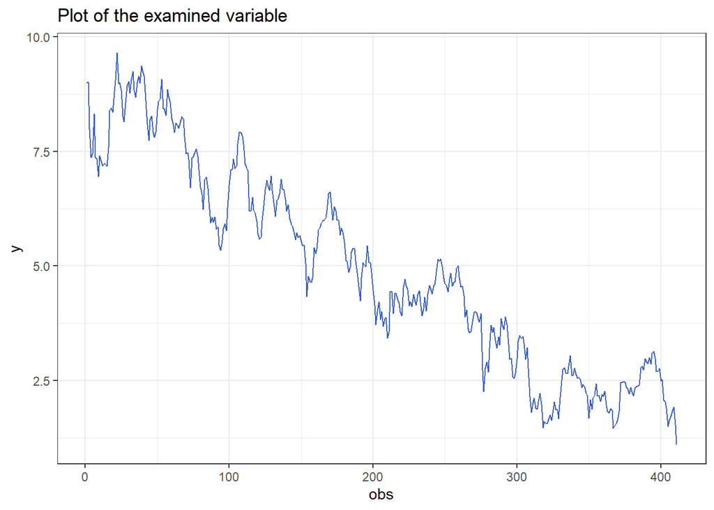

```
##   augmentations        adf     p_adf     bgodfrey      p_bg
## 1             0 -1.3770131 0.5452274 1.032782e+00 0.3095062
## 2             1 -1.4479374 0.5187582 1.987901e-02 0.8878755
## 3             2 -1.0432023 0.6698069 9.390879e-02 0.7592655
## 4             3 -0.8990934 0.7235890 2.964376e-05 0.9956559
```

```r
testdf(variable=r3m_r10y$r10y,max.augmentations = 3)
```

P-value of both data sets are much larger than 0.05, so we cannot reject the null hypothesis of DF test assuming non-stationarity.

Now let’s difference r3m and r10y

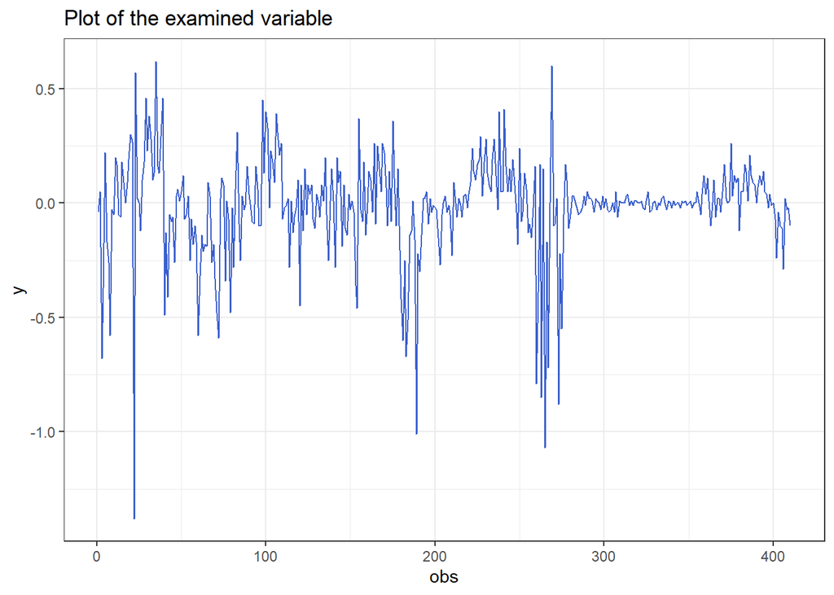

```
##   augmentations        adf p_adf    bgodfrey      p_bg
## 1             0 -16.529728  0.01 0.799980396 0.3710992
## 2             1 -10.137342  0.01 0.372940860 0.5414056
## 3             2  -7.889959  0.01 0.172209335 0.6781557
## 4             3  -6.971509  0.01 0.001075435 0.9738390
```

```r
testdf(variable = diff(r3m_r10y$r3m),max.augmentations = 3)
```

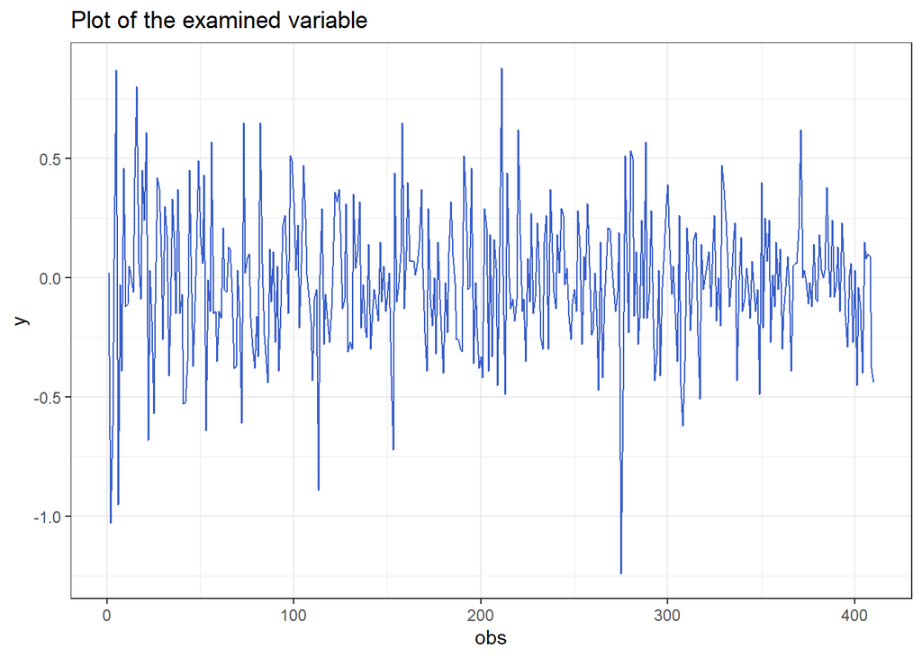

```
##   augmentations       adf p_adf     bgodfrey      p_bg
## 1             0 -19.19941  0.01 1.323846e-02 0.9083988
## 2             1 -15.44866  0.01 1.112030e-01 0.7387787
## 3             2 -12.35971  0.01 2.697072e-06 0.9986897
## 4             3 -10.07593  0.01 4.663018e-03 0.9455577
```

```r
testdf(variable = diff(r3m_r10y$r10y),max.augmentations = 3)
```

After the first differencing, both become stationary because p-value is much smaller than 0.05. Therefore they are both integrated of the order 1.

Let’s run a linear regression.

```r
r3m_r10y_line<- lm(r3m_r10y$r10y~r3m_r10y$r3m,data=r3m_r10y)
summary(r3m_r10y_line)
```

```
##
## Call:
## lm(formula = r3m_r10y$r10y ~ r3m_r10y$r3m, data = r3m_r10y)
##
## Residuals:
##      Min       1Q   Median       3Q      Max
## -2.44546 -0.78309  0.02072  0.81120  2.41854
##
## Coefficients:
##              Estimate Std. Error t value Pr(>|t|)
## (Intercept)   2.39147    0.07971   30.00   <2e-16 ***
## r3m_r10y$r3m  0.78090    0.01929   40.49   <2e-16 ***
## ---
## Signif. codes:  0 '***' 0.001 '**' 0.01 '*' 0.05 '.' 0.1 ' ' 1
##
## Residual standard error: 0.9954 on 409 degrees of freedom
## Multiple R-squared:  0.8003, Adjusted R-squared:  0.7998
## F-statistic:  1639 on 1 and 409 DF,  p-value: < 2.2e-16
```

r10m=0.78090*r3m+2.39147+e_t

Don’t forget to check whether there is autocorrelation in its residuals!

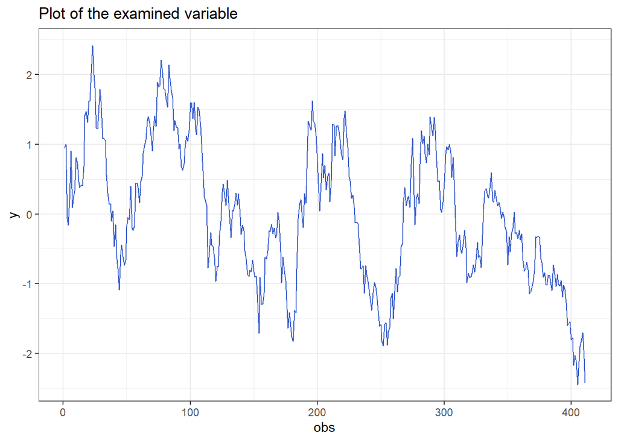

```
##   augmentations       adf     p_adf     bgodfrey      p_bg
## 1             0 -2.482720 0.1325732 0.2073617164 0.6488432
## 2             1 -2.534380 0.1132934 0.0086192398 0.9260308
## 3             2 -2.142973 0.2593680 0.0008455912 0.9768015
## 4             3 -2.249729 0.2195265 0.0020351360 0.9640177
```

```r
testdf(variable = residuals(r3m_r10y_line),max.augmentations = 3)
```

We could also perform granger casuality test:

```r
granger1<-grangertest(r10y~r3m,data=r3m_r10y,order=3)
granger1
```

```
## Granger causality test
##
## Model 1: r10y ~ Lags(r10y, 1:3) + Lags(r3m, 1:3)
## Model 2: r10y ~ Lags(r10y, 1:3)
##   Res.Df Df      F Pr(>F)
## 1    401
## 2    404 -3 0.5184 0.6699
```

```r
granger2<-grangertest(r10y~r3m,data=r3m_r10y,order=5)
granger2
```

```
## Granger causality test
##
## Model 1: r10y ~ Lags(r10y, 1:5) + Lags(r3m, 1:5)
## Model 2: r10y ~ Lags(r10y, 1:5)
##   Res.Df Df      F Pr(>F)
## 1    395
## 2    400 -5 0.6425 0.6674
```

```r
granger3<-grangertest(r3m~r10y,data=r3m_r10y,order=3)
granger3
```

```
## Granger causality test
##
## Model 1: r3m ~ Lags(r3m, 1:3) + Lags(r10y, 1:3)
## Model 2: r3m ~ Lags(r3m, 1:3)
##   Res.Df Df      F    Pr(>F)
## 1    401
## 2    404 -3 5.6354 0.0008622 ***
## ---
## Signif. codes:  0 '***' 0.001 '**' 0.01 '*' 0.05 '.' 0.1 ' ' 1
```

```r
granger4<-grangertest(r3m~r10y,data=r3m_r10y,order=5)
granger4
```

```
## Granger causality test
##
## Model 1: r3m ~ Lags(r3m, 1:5) + Lags(r10y, 1:5)
## Model 2: r3m ~ Lags(r3m, 1:5)
##   Res.Df Df      F   Pr(>F)
## 1    395
## 2    400 -5 3.7321 0.002591 **
## ---
## Signif. codes:  0 '***' 0.001 '**' 0.01 '*' 0.05 '.' 0.1 ' ' 1
```

We could confirm that r10y granger causes r3m.

## ECM(Error Correction Mechanism)

```r
r3m_r10y$residual=lag.xts(x=resid(r3m_r10y_line),k=1)
r3m_d<-diff(x=r3m_r10y$r3m)
r10y_d<-diff(x=r3m_r10y$r10y)
r3m_r10y_ecm=lm(r10y_d~r3m_d+r3m_r10y$residual,data=r3m_r10y)
summary(r3m_r10y_ecm)
```

```
##
## Call:
## lm(formula = r10y_d ~ r3m_d + r3m_r10y$residual, data = r3m_r10y)
##
## Residuals:
##      Min       1Q   Median       3Q      Max
## -1.01117 -0.16198 -0.01028  0.14733  0.86842
##
## Coefficients:
##                   Estimate Std. Error t value Pr(>|t|)
## (Intercept)       -0.01322    0.01344  -0.984    0.326
## r3m_d              0.41732    0.06157   6.778  4.3e-11 ***
## r3m_r10y$residual -0.02652    0.01366  -1.941    0.053 .
## ---
## Signif. codes:  0 '***' 0.001 '**' 0.01 '*' 0.05 '.' 0.1 ' ' 1
##
## Residual standard error: 0.2715 on 407 degrees of freedom
##   (因为不存在，1个观察量被删除了)
## Multiple R-squared:  0.1044, Adjusted R-squared:    0.1
## F-statistic: 23.72 on 2 and 407 DF,  p-value: 1.801e-10
```

Intercept is insignificant, so let’s remove it.

```r
r3m_r10y_ecm=lm(r10y_d~r3m_d+r3m_r10y$residual-1,data=r3m_r10y)
summary(r3m_r10y_ecm)
```

```
##
## Call:
## lm(formula = r10y_d ~ r3m_d + r3m_r10y$residual - 1, data = r3m_r10y)
##
## Residuals:
##      Min       1Q   Median       3Q      Max
## -1.02442 -0.17560 -0.02298  0.13420  0.85493
##
## Coefficients:
##                   Estimate Std. Error t value Pr(>|t|)
## r3m_d              0.42128    0.06144   6.857 2.61e-11 ***
## r3m_r10y$residual -0.02669    0.01366  -1.954   0.0514 .
## ---
## Signif. codes:  0 '***' 0.001 '**' 0.01 '*' 0.05 '.' 0.1 ' ' 1
##
## Residual standard error: 0.2715 on 408 degrees of freedom
##   (因为不存在，1个观察量被删除了)
## Multiple R-squared:  0.1063, Adjusted R-squared:  0.1019
## F-statistic: 24.27 on 2 and 408 DF,  p-value: 1.097e-10
```

r10y_d=0.42128 * r3m_d -0.02669 * (r10m-0.78090*r3m-2.39147)+e_t.

```r
1/0.02669
```

```
## [1] 37.46722
```

It takes around 37.46 periods to clear errors

## Select VAR models

```r
r3m_r10y<-r3m_r10y[,-3]
VARselect(r3m_r10y,lag.max =8,season = 12)
```

```
## $selection
## AIC(n)  HQ(n)  SC(n) FPE(n)
##      7      3      3      7
##
## $criteria
##                   1            2          3            4            5
## AIC(n) -5.718241440 -5.756391597 -5.8346822 -5.842743240 -5.838685892
## HQ(n)  -5.608244904 -5.630681270 -5.6932580 -5.685605332 -5.665834193
## SC(n)  -5.440399693 -5.438858173 -5.4774571 -5.445826460 -5.402077434
## FPE(n)  0.003285667  0.003162767  0.0029247  0.002901347  0.002913301
##                   6            7            8
## AIC(n) -5.852321573 -5.865407059 -5.853023842
## HQ(n)  -5.663756082 -5.661127778 -5.633030770
## SC(n)  -5.376021436 -5.349415245 -5.297340350
## FPE(n)  0.002874032  0.002836887  0.002872492
```

Information criteria suggests VAR(7) and VAR(3).

We could also visualize the result above:

```r
VARselect(r3m_r10y,lag.max =8,season = 12)%>%
  .$criteria %>%
  t() %>%
  as_tibble() %>%
  mutate(number_of_lags=1:nrow(.)) %>%
  kbl(digits=3) %>%
  kable_classic("striped",full_width=F)
```

| AIC(n) | HQ(n) | SC(n) | FPE(n) | number_of_lags |
| --- | --- | --- | --- | --- |
| -5.718 | -5.608 | -5.440 | 0.003 | 1 |
| -5.756 | -5.631 | -5.439 | 0.003 | 2 |
| -5.835 | -5.693 | -5.477 | 0.003 | 3 |
| -5.843 | -5.686 | -5.446 | 0.003 | 4 |
| -5.839 | -5.666 | -5.402 | 0.003 | 5 |
| -5.852 | -5.664 | -5.376 | 0.003 | 6 |
| -5.865 | -5.661 | -5.349 | 0.003 | 7 |
| -5.853 | -5.633 | -5.297 | 0.003 | 8 |

Let’s start with VAR(3):

```r
r3m_r10y.var3<-VAR(r3m_r10y,
                   p=3,
                   season=12)
summary(r3m_r10y.var3)
```

```
##
## VAR Estimation Results:
## =========================
## Endogenous variables: r3m, r10y
## Deterministic variables: const
## Sample size: 408
## Log Likelihood: 55.982
## Roots of the characteristic polynomial:
## 0.9936 0.9639 0.5931 0.4603 0.3212 0.3212
## Call:
## VAR(y = r3m_r10y, p = 3, season = 12L)
##
##
## Estimation results for equation r3m:
## ====================================
## r3m = r3m.l1 + r10y.l1 + r3m.l2 + r10y.l2 + r3m.l3 + r10y.l3 + const + sd1 + sd2 + sd3 + sd4 + sd5 + sd6 + sd7 + sd8 + sd9 + sd10 + sd11
##
##          Estimate Std. Error t value Pr(>|t|)
## r3m.l1   1.084289   0.051788  20.937  < 2e-16 ***
## r10y.l1  0.132573   0.038404   3.452 0.000617 ***
## r3m.l2   0.163807   0.078068   2.098 0.036525 *
## r10y.l2 -0.114214   0.054055  -2.113 0.035242 *
## r3m.l3  -0.267734   0.050551  -5.296 1.98e-07 ***
## r10y.l3 -0.001456   0.038942  -0.037 0.970195
## const   -0.026491   0.030211  -0.877 0.381099
## sd1     -0.089109   0.049716  -1.792 0.073848 .
## sd2     -0.080368   0.049902  -1.610 0.108099
## sd3      0.004789   0.049566   0.097 0.923071
## sd4     -0.080179   0.049709  -1.613 0.107562
## sd5     -0.117537   0.050039  -2.349 0.019327 *
## sd6     -0.007822   0.049816  -0.157 0.875305
## sd7     -0.061165   0.049980  -1.224 0.221768
## sd8     -0.023219   0.050207  -0.462 0.643996
## sd9     -0.083401   0.049792  -1.675 0.094735 .
## sd10    -0.160885   0.050216  -3.204 0.001468 **
## sd11    -0.051955   0.049941  -1.040 0.298831
## ---
## Signif. codes:  0 '***' 0.001 '**' 0.01 '*' 0.05 '.' 0.1 ' ' 1
##
##
```

[output cut: 32 more lines]

```
## Residual standard error: 0.2805 on 390 degrees of freedom
## Multiple R-Squared: 0.9846,  Adjusted R-squared: 0.9839
## F-statistic:  1463 on 17 and 390 DF,  p-value: < 2.2e-16
##
##
##
## Covariance matrix of residuals:
##          r3m    r10y
## r3m  0.04147 0.02027
## r10y 0.02027 0.07867
##
## Correlation matrix of residuals:
##        r3m  r10y
## r3m  1.000 0.355
## r10y 0.355 1.000
```

Most seasonal dummies are insignificant, so let’s remove them.

```r
r3m_r10y.var3<-VAR(r3m_r10y,
                   p=3,
                   )
summary(r3m_r10y.var3)
```

```
##
## VAR Estimation Results:
## =========================
## Endogenous variables: r3m, r10y
## Deterministic variables: const
## Sample size: 408
## Log Likelihood: 33.819
## Roots of the characteristic polynomial:
## 0.9934 0.9647 0.5626 0.4348 0.3271 0.3271
## Call:
## VAR(y = r3m_r10y, p = 3)
##
##
## Estimation results for equation r3m:
## ====================================
## r3m = r3m.l1 + r10y.l1 + r3m.l2 + r10y.l2 + r3m.l3 + r10y.l3 + const
##
##          Estimate Std. Error t value Pr(>|t|)
## r3m.l1   1.073665   0.051088  21.016  < 2e-16 ***
## r10y.l1  0.148124   0.037982   3.900 0.000113 ***
## r3m.l2   0.147364   0.076432   1.928 0.054554 .
## r10y.l2 -0.122457   0.053704  -2.280 0.023119 *
## r3m.l3  -0.241066   0.049736  -4.847  1.8e-06 ***
## r10y.l3 -0.008415   0.038643  -0.218 0.827726
## const   -0.027026   0.030574  -0.884 0.377260
## ---
## Signif. codes:  0 '***' 0.001 '**' 0.01 '*' 0.05 '.' 0.1 ' ' 1
##
##
## Residual standard error: 0.2064 on 401 degrees of freedom
## Multiple R-Squared: 0.9935,  Adjusted R-squared: 0.9934
## F-statistic: 1.016e+04 on 6 and 401 DF,  p-value: < 2.2e-16
##
##
## Estimation results for equation r10y:
## =====================================
## r10y = r3m.l1 + r10y.l1 + r3m.l2 + r10y.l2 + r3m.l3 + r10y.l3 + const
##
##         Estimate Std. Error t value Pr(>|t|)
## r3m.l1  -0.03377    0.06977  -0.484   0.6287
```

[output cut: 10 more lines]

```
## Residual standard error: 0.2819 on 401 degrees of freedom
## Multiple R-Squared: 0.984,   Adjusted R-squared: 0.9837
## F-statistic:  4098 on 6 and 401 DF,  p-value: < 2.2e-16
##
##
##
## Covariance matrix of residuals:
##          r3m    r10y
## r3m  0.04262 0.01952
## r10y 0.01952 0.07949
##
## Correlation matrix of residuals:
##         r3m   r10y
## r3m  1.0000 0.3354
## r10y 0.3354 1.0000
```

Let’s diagnose its residual

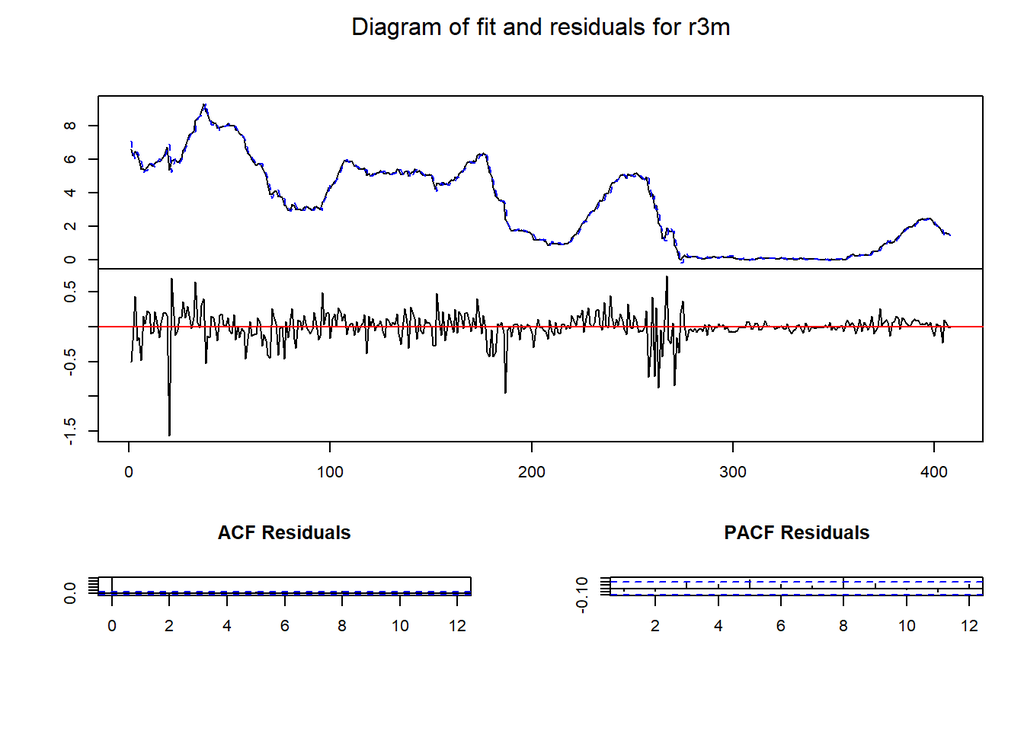

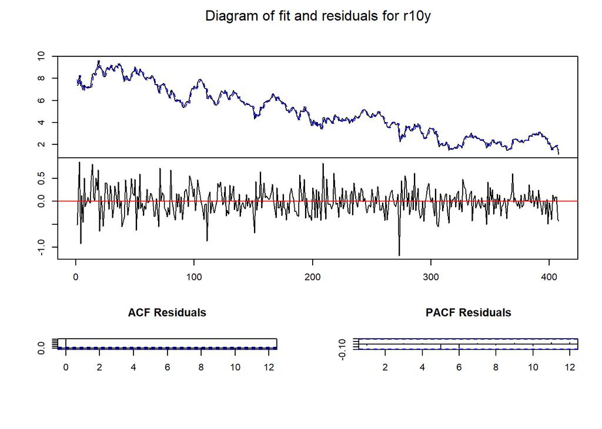

```r
plot(r3m_r10y.var3)
```

```r
serial.test(r3m_r10y.var3)
```

```
##
##  Portmanteau Test (asymptotic)
##
## data:  Residuals of VAR object r3m_r10y.var3
## Chi-squared = 107.82, df = 52, p-value = 8.871e-06
```

```r
serial.test(r3m_r10y.var3,type=c("BG"))
```

```
##
##  Breusch-Godfrey LM test
##
## data:  Residuals of VAR object r3m_r10y.var3
## Chi-squared = 62.295, df = 20, p-value = 3.125e-06
```

Null hypothesis of no autocorrelation should be rejected based on very small p-value. So there is autocorrelation in the residual.

VAR(7):

```r
r3m_r10y.var7<-VAR(r3m_r10y,
                   p=7,
                   season = 12)
summary(r3m_r10y.var7)
```

```
##
## VAR Estimation Results:
## =========================
## Endogenous variables: r3m, r10y
## Deterministic variables: const
## Sample size: 404
## Log Likelihood: 90.481
## Roots of the characteristic polynomial:
## 0.9958 0.9435 0.9435  0.73  0.73 0.6987 0.6987 0.6912 0.6912 0.672 0.672 0.6546 0.5771 0.5771
## Call:
## VAR(y = r3m_r10y, p = 7, season = 12L)
##
##
## Estimation results for equation r3m:
## ====================================
## r3m = r3m.l1 + r10y.l1 + r3m.l2 + r10y.l2 + r3m.l3 + r10y.l3 + r3m.l4 + r10y.l4 + r3m.l5 + r10y.l5 + r3m.l6 + r10y.l6 + r3m.l7 + r10y.l7 + const + sd1 + sd2 + sd3 + sd4 + sd5 + sd6 + sd7 + sd8 + sd9 + sd10 + sd11
##
##           Estimate Std. Error t value Pr(>|t|)
## r3m.l1   1.0041558  0.0540552  18.576  < 2e-16 ***
## r10y.l1  0.1350800  0.0387774   3.483 0.000553 ***
## r3m.l2   0.1696127  0.0768771   2.206 0.027965 *
## r10y.l2 -0.0700067  0.0537828  -1.302 0.193826
## r3m.l3  -0.0969172  0.0769436  -1.260 0.208595
## r10y.l3 -0.0645594  0.0534573  -1.208 0.227925
## r3m.l4  -0.0619571  0.0768789  -0.806 0.420804
## r10y.l4  0.0699766  0.0535828   1.306 0.192363
## r3m.l5   0.1105256  0.0761868   1.451 0.147688
## r10y.l5 -0.1147686  0.0533607  -2.151 0.032125 *
## r3m.l6  -0.0281251  0.0761419  -0.369 0.712053
## r10y.l6 -0.0056677  0.0534096  -0.106 0.915545
## r3m.l7  -0.1299815  0.0522787  -2.486 0.013338 *
## r10y.l7  0.0813770  0.0382127   2.130 0.033852 *
## const   -0.0528032  0.0302576  -1.745 0.081777 .
## sd1     -0.0628544  0.0485305  -1.295 0.196059
## sd2     -0.0593449  0.0489516  -1.212 0.226148
## sd3      0.0257732  0.0484190   0.532 0.594834
## sd4     -0.0225971  0.0491943  -0.459 0.646251
## sd5     -0.0887659  0.0491121  -1.807 0.071492 .
## sd6     -0.0095563  0.0488857  -0.195 0.845121
## sd7     -0.0331169  0.0491997  -0.673 0.501288
```

[output cut: 48 more lines]

```
## Residual standard error: 0.2726 on 378 degrees of freedom
## Multiple R-Squared: 0.9856,  Adjusted R-squared: 0.9847
## F-statistic:  1037 on 25 and 378 DF,  p-value: < 2.2e-16
##
##
##
## Covariance matrix of residuals:
##          r3m    r10y
## r3m  0.03820 0.01837
## r10y 0.01837 0.07434
##
## Correlation matrix of residuals:
##         r3m   r10y
## r3m  1.0000 0.3448
## r10y 0.3448 1.0000
```

Seasonal dummies are insignificant, so let’s remove them.

```r
r3m_r10y.var7<-VAR(r3m_r10y,
                   p=7)
summary(r3m_r10y.var7)
```

```
##
## VAR Estimation Results:
## =========================
## Endogenous variables: r3m, r10y
## Deterministic variables: const
## Sample size: 404
## Log Likelihood: 71.734
## Roots of the characteristic polynomial:
## 0.9957 0.9437 0.9437 0.7472 0.7472 0.7453 0.7453 0.707 0.707 0.6812 0.6812 0.6747 0.6007 0.6007
## Call:
## VAR(y = r3m_r10y, p = 7)
##
##
## Estimation results for equation r3m:
## ====================================
## r3m = r3m.l1 + r10y.l1 + r3m.l2 + r10y.l2 + r3m.l3 + r10y.l3 + r3m.l4 + r10y.l4 + r3m.l5 + r10y.l5 + r3m.l6 + r10y.l6 + r3m.l7 + r10y.l7 + const
##
##          Estimate Std. Error t value Pr(>|t|)
## r3m.l1   0.995107   0.052798  18.847  < 2e-16 ***
## r10y.l1  0.144350   0.037823   3.816 0.000157 ***
## r3m.l2   0.152383   0.074880   2.035 0.042526 *
## r10y.l2 -0.070803   0.052888  -1.339 0.181435
## r3m.l3  -0.063405   0.074614  -0.850 0.395972
## r10y.l3 -0.064247   0.052769  -1.218 0.224149
## r3m.l4  -0.059611   0.074483  -0.800 0.424004
## r10y.l4  0.067775   0.052958   1.280 0.201383
## r3m.l5   0.103603   0.073880   1.402 0.161621
## r10y.l5 -0.133013   0.052749  -2.522 0.012081 *
## r3m.l6  -0.026982   0.073832  -0.365 0.714972
## r10y.l6 -0.007623   0.052864  -0.144 0.885420
## r3m.l7  -0.134680   0.050772  -2.653 0.008313 **
## r10y.l7  0.095893   0.037714   2.543 0.011388 *
## const   -0.054430   0.030424  -1.789 0.074386 .
## ---
## Signif. codes:  0 '***' 0.001 '**' 0.01 '*' 0.05 '.' 0.1 ' ' 1
##
##
## Residual standard error: 0.1967 on 389 degrees of freedom
## Multiple R-Squared: 0.9942,  Adjusted R-squared: 0.9939
## F-statistic:  4727 on 14 and 389 DF,  p-value: < 2.2e-16
```

[output cut: 26 more lines]

```
## Residual standard error: 0.2743 on 389 degrees of freedom
## Multiple R-Squared: 0.985,   Adjusted R-squared: 0.9845
## F-statistic:  1830 on 14 and 389 DF,  p-value: < 2.2e-16
##
##
##
## Covariance matrix of residuals:
##          r3m    r10y
## r3m  0.03869 0.01783
## r10y 0.01783 0.07522
##
## Correlation matrix of residuals:
##         r3m   r10y
## r3m  1.0000 0.3305
## r10y 0.3305 1.0000
```

Let’s diagnoze its residual

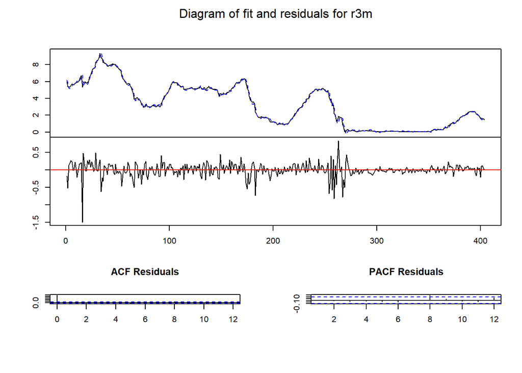

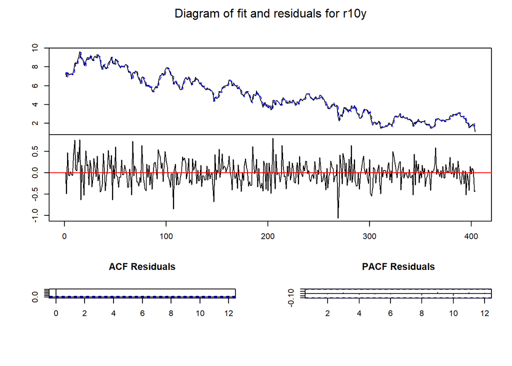

```r
plot(r3m_r10y.var7)
```

```r
serial.test(r3m_r10y.var7)
```

```
##
##  Portmanteau Test (asymptotic)
##
## data:  Residuals of VAR object r3m_r10y.var7
## Chi-squared = 54.8, df = 36, p-value = 0.02316
```

```r
serial.test(r3m_r10y.var7,type=c("BG"))
```

```
##
##  Breusch-Godfrey LM test
##
## data:  Residuals of VAR object r3m_r10y.var7
## Chi-squared = 31.348, df = 20, p-value = 0.05075
```

Although there is autocorelation in its residual according to Portmanteau test, it passes BG test. So let’s keep VAR(7).

VAR(6):

```r
r3m_r10y.var6<-VAR(r3m_r10y,p=6)
summary(r3m_r10y.var6)
```

```
##
## VAR Estimation Results:
## =========================
## Endogenous variables: r3m, r10y
## Deterministic variables: const
## Sample size: 405
## Log Likelihood: 58.388
## Roots of the characteristic polynomial:
## 0.9931 0.9137 0.9137 0.643 0.643 0.6296 0.6296 0.6202 0.6202 0.5879 0.5879 0.5417
## Call:
## VAR(y = r3m_r10y, p = 6)
##
##
## Estimation results for equation r3m:
## ====================================
## r3m = r3m.l1 + r10y.l1 + r3m.l2 + r10y.l2 + r3m.l3 + r10y.l3 + r3m.l4 + r10y.l4 + r3m.l5 + r10y.l5 + r3m.l6 + r10y.l6 + const
##
##         Estimate Std. Error t value Pr(>|t|)
## r3m.l1   1.02119    0.05257  19.425  < 2e-16 ***
## r10y.l1  0.14474    0.03776   3.833 0.000147 ***
## r3m.l2   0.13300    0.07502   1.773 0.077016 .
## r10y.l2 -0.08690    0.05287  -1.644 0.101039
## r3m.l3  -0.04704    0.07513  -0.626 0.531575
## r10y.l3 -0.05522    0.05319  -1.038 0.299843
## r3m.l4  -0.06893    0.07434  -0.927 0.354400
## r10y.l4  0.07694    0.05311   1.449 0.148223
## r3m.l5   0.08593    0.07428   1.157 0.248027
## r10y.l5 -0.15017    0.05272  -2.848 0.004628 **
## r3m.l6  -0.15176    0.05063  -2.997 0.002898 **
## r10y.l6  0.09619    0.03763   2.556 0.010949 *
## const   -0.04022    0.03032  -1.327 0.185397
## ---
## Signif. codes:  0 '***' 0.001 '**' 0.01 '*' 0.05 '.' 0.1 ' ' 1
##
##
## Residual standard error: 0.1986 on 392 degrees of freedom
## Multiple R-Squared: 0.994,   Adjusted R-squared: 0.9938
## F-statistic:  5428 on 12 and 392 DF,  p-value: < 2.2e-16
##
##
```

[output cut: 22 more lines]

```
## Residual standard error: 0.2781 on 392 degrees of freedom
## Multiple R-Squared: 0.9845,  Adjusted R-squared: 0.9841
## F-statistic:  2081 on 12 and 392 DF,  p-value: < 2.2e-16
##
##
##
## Covariance matrix of residuals:
##          r3m    r10y
## r3m  0.03944 0.01756
## r10y 0.01756 0.07735
##
## Correlation matrix of residuals:
##        r3m  r10y
## r3m  1.000 0.318
## r10y 0.318 1.000
```

```r
serial.test(r3m_r10y.var6)
```

```
##
##  Portmanteau Test (asymptotic)
##
## data:  Residuals of VAR object r3m_r10y.var6
## Chi-squared = 81.954, df = 40, p-value = 0.000103
```

```r
serial.test(r3m_r10y.var6,type=c("BG"))
```

```
##
##  Breusch-Godfrey LM test
##
## data:  Residuals of VAR object r3m_r10y.var6
## Chi-squared = 59.967, df = 20, p-value = 7.206e-06
```

There is autocorrelation in it, so VAR(6) should not be considered.

VAR(9):

```r
r3m_r10y.var9<-VAR(r3m_r10y,p=9)
summary(r3m_r10y.var9)
```

```
##
## VAR Estimation Results:
## =========================
## Endogenous variables: r3m, r10y
## Deterministic variables: const
## Sample size: 402
## Log Likelihood: 83.468
## Roots of the characteristic polynomial:
## 0.9967 0.9586 0.9586 0.8226 0.7939 0.7939 0.7418 0.7418 0.7368 0.7368 0.7349 0.7349 0.6435 0.6435 0.5307 0.5307 0.3699 0.3699
## Call:
## VAR(y = r3m_r10y, p = 9)
##
##
## Estimation results for equation r3m:
## ====================================
## r3m = r3m.l1 + r10y.l1 + r3m.l2 + r10y.l2 + r3m.l3 + r10y.l3 + r3m.l4 + r10y.l4 + r3m.l5 + r10y.l5 + r3m.l6 + r10y.l6 + r3m.l7 + r10y.l7 + r3m.l8 + r10y.l8 + r3m.l9 + r10y.l9 + const
##
##         Estimate Std. Error t value Pr(>|t|)
## r3m.l1   0.99405    0.05274  18.848  < 2e-16 ***
## r10y.l1  0.14925    0.03783   3.945 9.48e-05 ***
## r3m.l2   0.13177    0.07417   1.777 0.076422 .
## r10y.l2 -0.06584    0.05339  -1.233 0.218207
## r3m.l3  -0.07351    0.07351  -1.000 0.317935
## r10y.l3 -0.05529    0.05336  -1.036 0.300759
## r3m.l4  -0.05368    0.07364  -0.729 0.466499
## r10y.l4  0.06954    0.05243   1.327 0.185460
## r3m.l5   0.08311    0.07314   1.136 0.256507
## r10y.l5 -0.14533    0.05195  -2.797 0.005411 **
## r3m.l6  -0.01295    0.07320  -0.177 0.859695
## r10y.l6 -0.01902    0.05230  -0.364 0.716238
## r3m.l7  -0.10727    0.07278  -1.474 0.141332
## r10y.l7  0.17401    0.05222   3.332 0.000945 ***
## r3m.l8   0.18508    0.07279   2.543 0.011393 *
## r10y.l8 -0.11905    0.05243  -2.271 0.023728 *
## r3m.l9  -0.18535    0.05054  -3.667 0.000280 ***
## r10y.l9  0.05035    0.03727   1.351 0.177533
## const   -0.06543    0.03053  -2.143 0.032731 *
## ---
## Signif. codes:  0 '***' 0.001 '**' 0.01 '*' 0.05 '.' 0.1 ' ' 1
##
```

[output cut: 34 more lines]

```
## Residual standard error: 0.2744 on 383 degrees of freedom
## Multiple R-Squared: 0.9852,  Adjusted R-squared: 0.9845
## F-statistic:  1415 on 18 and 383 DF,  p-value: < 2.2e-16
##
##
##
## Covariance matrix of residuals:
##          r3m    r10y
## r3m  0.03688 0.01682
## r10y 0.01682 0.07528
##
## Correlation matrix of residuals:
##         r3m   r10y
## r3m  1.0000 0.3193
## r10y 0.3193 1.0000
```

```r
serial.test(r3m_r10y.var9)
```

```
##
##  Portmanteau Test (asymptotic)
##
## data:  Residuals of VAR object r3m_r10y.var9
## Chi-squared = 37.206, df = 28, p-value = 0.1144
```

```r
serial.test(r3m_r10y.var9,type=c("BG"))
```

```
##
##  Breusch-Godfrey LM test
##
## data:  Residuals of VAR object r3m_r10y.var9
## Chi-squared = 19.46, df = 20, p-value = 0.4921
```

VAR(9) could also work since we cannot reject the null hypothesis assuming no autocorelation in Portmanteau test and BG test.

Let’s use information criteria to see which one is better

```r
AIC(r3m_r10y.var9,r3m_r10y.var7)
```

```
##               df       AIC
## r3m_r10y.var9 38 -90.93648
## r3m_r10y.var7 30 -83.46813
```

```r
BIC(r3m_r10y.var9,r3m_r10y.var7)
```

```
##               df      BIC
## r3m_r10y.var9 38 60.92870
## r3m_r10y.var7 30 36.57432
```

Let’s use VAR(7)

## Impulse Response Functions

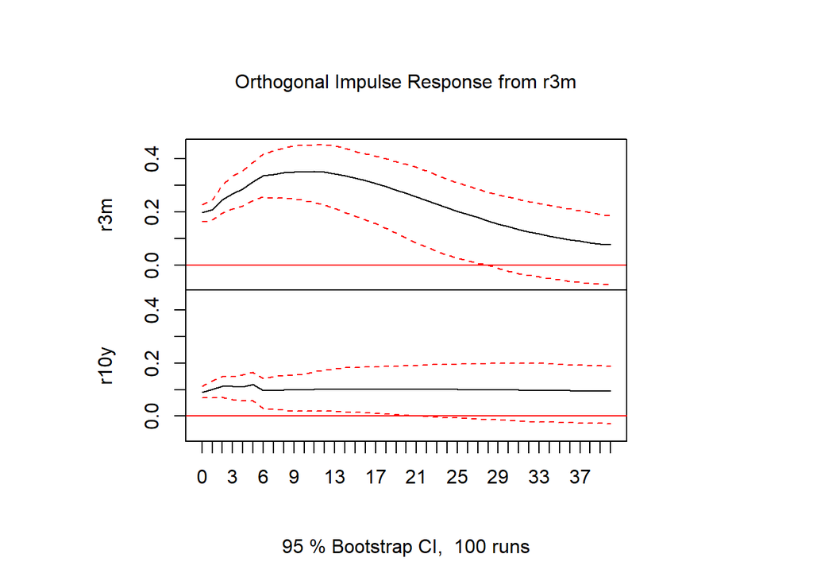

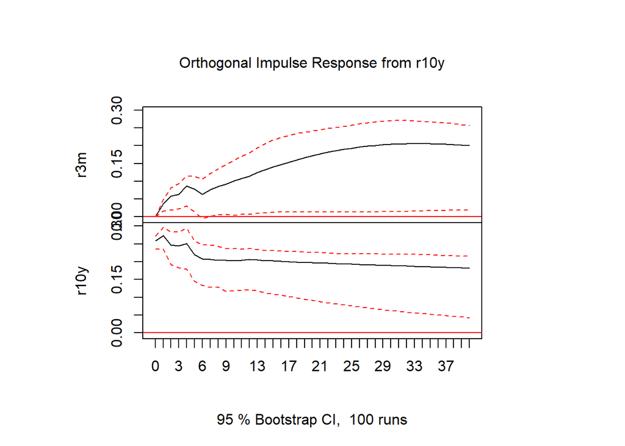

```r
plot(irf(r3m_r10y.var7,n.ahead = 40))
```

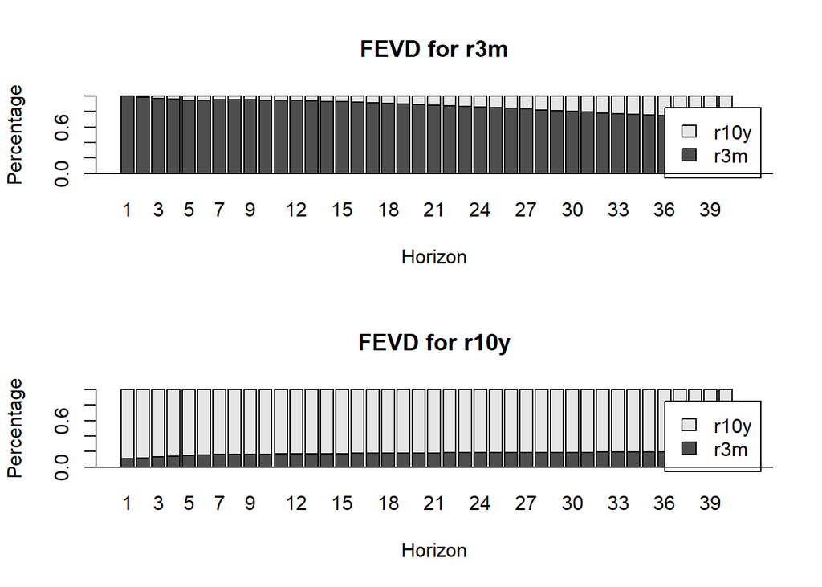

```r
plot(fevd(r3m_r10y.var7,n.ahead = 40))
```

## Forecast 12-month periods ahead with VAR(7)

Let’s cut the data in the last 12-month periods

```r
tail(r3m_r10y,13)
```

```
##             r3m r10y
## 2019-03-01 2.45 2.76
## 2019-04-01 2.44 2.49
## 2019-05-01 2.44 2.52
## 2019-06-03 2.37 2.07
## 2019-07-01 2.13 2.03
## 2019-08-01 2.09 1.90
## 2019-09-02 1.99 1.50
## 2019-10-01 1.88 1.65
## 2019-11-01 1.59 1.73
## 2019-12-02 1.61 1.83
## 2020-01-01 1.58 1.92
## 2020-02-03 1.56 1.54
## 2020-03-02 1.46 1.10
```

```r
r3m_r10y.short<-r3m_r10y["/2019-03-01"]
tail(r3m_r10y.short,12)
```

```
##             r3m r10y
## 2018-04-02 1.76 2.73
## 2018-05-01 1.85 2.97
## 2018-06-01 1.93 2.89
## 2018-07-02 1.93 2.87
## 2018-08-01 2.00 3.00
## 2018-09-03 2.12 2.86
## 2018-10-01 2.20 3.09
## 2018-11-01 2.34 3.14
## 2018-12-03 2.39 2.98
## 2019-01-01 2.43 2.69
## 2019-02-01 2.41 2.70
## 2019-03-01 2.45 2.76
```

Let’s use VAR(7) to fit the shorten data set

```r
r3m_r10y.short.var7<-VAR(r3m_r10y.short,
                         p=7)
```

Let’s perform forecasting

```r
r3m_r10y.forecast<-predict(r3m_r10y.short.var7,
                           n.ahead = 12,
                           ci=0.95)

r3m_r10y.forecast
```

```
## $r3m
##           fcst       lower    upper        CI
##  [1,] 2.421096  2.03096453 2.811228 0.3901319
##  [2,] 2.406777  1.83266137 2.980892 0.5741153
##  [3,] 2.415520  1.65279024 3.178250 0.7627297
##  [4,] 2.406906  1.46914003 3.344671 0.9377657
##  [5,] 2.364835  1.25460488 3.475065 1.1102300
##  [6,] 2.318065  1.03580313 3.600326 1.2822616
##  [7,] 2.264797  0.81352206 3.716071 1.4512747
##  [8,] 2.207857  0.59967284 3.816042 1.6081845
##  [9,] 2.148359  0.39057914 3.906138 1.7577796
## [10,] 2.084246  0.18449172 3.984001 1.8997545
## [11,] 2.017733 -0.01578279 4.051248 2.0335155
## [12,] 1.951340 -0.21020430 4.112884 2.1615441
##
## $r10y
##           fcst    lower    upper        CI
##  [1,] 2.770037 2.233417 3.306657 0.5366200
##  [2,] 2.787299 2.005747 3.568852 0.7815521
##  [3,] 2.847205 1.905476 3.788934 0.9417292
##  [4,] 2.873437 1.798610 3.948264 1.0748272
##  [5,] 2.892683 1.694806 4.090559 1.1978766
##  [6,] 2.902349 1.613588 4.191110 1.2887610
##  [7,] 2.918294 1.559460 4.277128 1.3588338
##  [8,] 2.928700 1.504179 4.353221 1.4245209
##  [9,] 2.936497 1.450835 4.422160 1.4856625
## [10,] 2.944358 1.400399 4.488318 1.5439598
## [11,] 2.956490 1.356822 4.556157 1.5996678
## [12,] 2.966788 1.312308 4.621269 1.6544807
```

Forecast data is stored in the column called “fcst”

forecast of three-month and ten-year treasury maturity rates

```r
r3m_r10y.forecast$fcst$r3m
```

```
##           fcst       lower    upper        CI
##  [1,] 2.421096  2.03096453 2.811228 0.3901319
##  [2,] 2.406777  1.83266137 2.980892 0.5741153
##  [3,] 2.415520  1.65279024 3.178250 0.7627297
##  [4,] 2.406906  1.46914003 3.344671 0.9377657
##  [5,] 2.364835  1.25460488 3.475065 1.1102300
##  [6,] 2.318065  1.03580313 3.600326 1.2822616
##  [7,] 2.264797  0.81352206 3.716071 1.4512747
##  [8,] 2.207857  0.59967284 3.816042 1.6081845
##  [9,] 2.148359  0.39057914 3.906138 1.7577796
## [10,] 2.084246  0.18449172 3.984001 1.8997545
## [11,] 2.017733 -0.01578279 4.051248 2.0335155
## [12,] 1.951340 -0.21020430 4.112884 2.1615441
```

```r
r3m_r10y.forecast$fcst$r10y
```

```
##           fcst    lower    upper        CI
##  [1,] 2.770037 2.233417 3.306657 0.5366200
##  [2,] 2.787299 2.005747 3.568852 0.7815521
##  [3,] 2.847205 1.905476 3.788934 0.9417292
##  [4,] 2.873437 1.798610 3.948264 1.0748272
##  [5,] 2.892683 1.694806 4.090559 1.1978766
##  [6,] 2.902349 1.613588 4.191110 1.2887610
##  [7,] 2.918294 1.559460 4.277128 1.3588338
##  [8,] 2.928700 1.504179 4.353221 1.4245209
##  [9,] 2.936497 1.450835 4.422160 1.4856625
## [10,] 2.944358 1.400399 4.488318 1.5439598
## [11,] 2.956490 1.356822 4.556157 1.5996678
## [12,] 2.966788 1.312308 4.621269 1.6544807
```

Let’s corcer them to “xts” and change the names of each column

```r
r3m_forecast<- xts(r3m_r10y.forecast$fcst$r3m[,-4],
                   tail(index(r3m_r10y),12))
names(r3m_forecast)<-c("r3m_forecast","r3m_lower","r3m_upper")


r10y_forecast<-xts(r3m_r10y.forecast$fcst$r10y[,-4],
                   tail(index(r3m_r10y),12) )
names(r10y_forecast)<-c("r10y_forecast","r10y_lower","r10y_upper")
```

Let’s merge them with the original dataset.

```r
r3m_r10y_merged<-merge(r3m_r10y,
  r3m_forecast,
  r10y_forecast
)

r3m_r10y_merged
```

```
##             r3m r10y r3m_forecast   r3m_lower r3m_upper r10y_forecast
## 1986-01-01 7.25 9.00           NA          NA        NA            NA
## 1986-02-03 7.21 9.02           NA          NA        NA            NA
## 1986-03-03 7.26 7.99           NA          NA        NA            NA
## 1986-04-01 6.58 7.37           NA          NA        NA            NA
## 1986-05-01 6.21 7.45           NA          NA        NA            NA
## 1986-06-02 6.43 8.32           NA          NA        NA            NA
## 1986-07-01 6.26 7.37           NA          NA        NA            NA
## 1986-08-01 6.00 7.34           NA          NA        NA            NA
## 1986-09-01 5.42 6.95           NA          NA        NA            NA
## 1986-10-01 5.39 7.41           NA          NA        NA            NA
##        ...
## 2019-06-03 2.37 2.07     2.415520  1.65279024  3.178250      2.847205
## 2019-07-01 2.13 2.03     2.406906  1.46914003  3.344671      2.873437
## 2019-08-01 2.09 1.90     2.364835  1.25460488  3.475065      2.892683
## 2019-09-02 1.99 1.50     2.318065  1.03580313  3.600326      2.902349
## 2019-10-01 1.88 1.65     2.264797  0.81352206  3.716071      2.918294
## 2019-11-01 1.59 1.73     2.207857  0.59967284  3.816042      2.928700
## 2019-12-02 1.61 1.83     2.148359  0.39057914  3.906138      2.936497
## 2020-01-01 1.58 1.92     2.084246  0.18449172  3.984001      2.944358
## 2020-02-03 1.56 1.54     2.017733 -0.01578279  4.051248      2.956490
## 2020-03-02 1.46 1.10     1.951340 -0.21020430  4.112884      2.966788
##            r10y_lower r10y_upper
## 1986-01-01         NA         NA
## 1986-02-03         NA         NA
## 1986-03-03         NA         NA
## 1986-04-01         NA         NA
## 1986-05-01         NA         NA
## 1986-06-02         NA         NA
## 1986-07-01         NA         NA
## 1986-08-01         NA         NA
## 1986-09-01         NA         NA
## 1986-10-01         NA         NA
##        ...
## 2019-06-03   1.905476   3.788934
## 2019-07-01   1.798610   3.948264
## 2019-08-01   1.694806   4.090559
## 2019-09-02   1.613588   4.191110
## 2019-10-01   1.559460   4.277128
## 2019-11-01   1.504179   4.353221
## 2019-12-02   1.450835   4.422160
## 2020-01-01   1.400399   4.488318
## 2020-02-03   1.356822   4.556157
## 2020-03-02   1.312308   4.621269
```

Let’s plot for r3m and r10y.

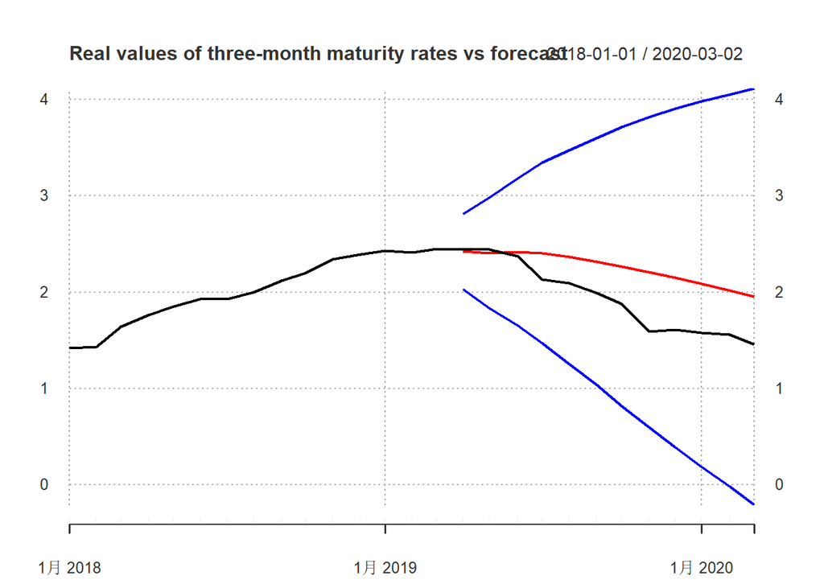

```r
plot(r3m_r10y_merged["2018/",c("r3m","r3m_forecast","r3m_lower","r3m_upper")],
     col=c("black","red","blue","blue"),
     major.ticks="years",
   grid.ticks.on="years",
   grid.ticks.lty=3,
   main="Real values of three-month maturity rates vs forecast"
)
```

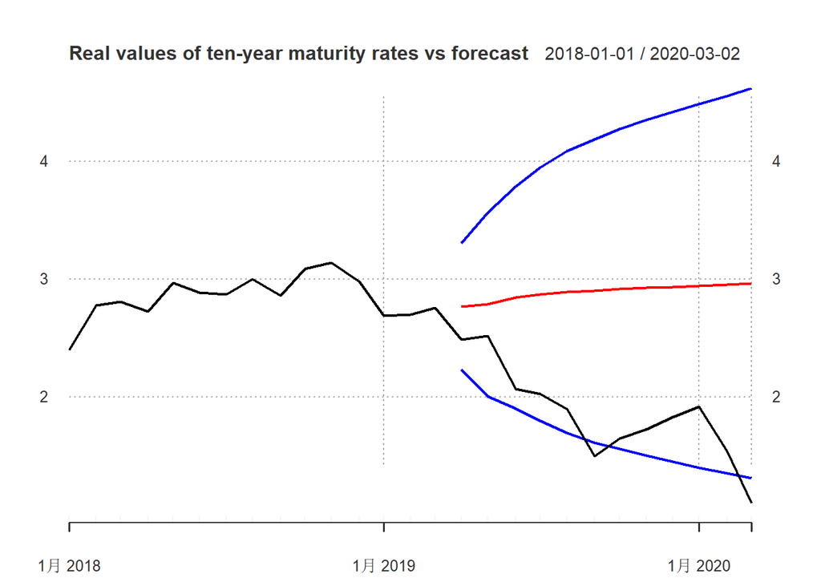

```r
plot(r3m_r10y_merged["2018/",c("r10y","r10y_forecast","r10y_lower","r10y_upper")],
     col=c("black","red","blue","blue"),
     major.ticks="years",
     grid.ticks.on="years",
     grid.ticks.lty=3,
     main="Real values of ten-year maturity rates vs forecast"
)
```

## Forecast Accuracy Measures

```r
r3m_r10y_merged$mae.r3m   <-  abs(r3m_r10y_merged$r3m - r3m_r10y_merged$r3m_forecast)
r3m_r10y_merged$mse.r3m   <-  (r3m_r10y_merged$r3m - r3m_r10y_merged$r3m_forecast) ^2
r3m_r10y_merged$mape.r3m  <-  abs((r3m_r10y_merged$r3m - r3m_r10y_merged$r3m_forecast)/r3m_r10y_merged$r3m)
r3m_r10y_merged$amape.r3m <-  abs((r3m_r10y_merged$r3m - r3m_r10y_merged$r3m_forecast) /
                            (r3m_r10y_merged$r3m + r3m_r10y_merged$r3m_forecast))


r3m_r10y_merged$mae.r10y   <-  abs(r3m_r10y_merged$r10y - r3m_r10y_merged$r10y_forecast)
r3m_r10y_merged$mse.r10y  <-  (r3m_r10y_merged$r10y - r3m_r10y_merged$r10y_forecast) ^2
r3m_r10y_merged$mape.r10y  <-  abs((r3m_r10y_merged$r10y - r3m_r10y_merged$r10y_forecast)/r3m_r10y_merged$r10y)
r3m_r10y_merged$amape.r10y <-  abs((r3m_r10y_merged$r10y - r3m_r10y_merged$r10y_forecast) /
                                    (r3m_r10y_merged$r10y + r3m_r10y_merged$r10y_forecast))

tail(r3m_r10y_merged,12)
```

```
##             r3m r10y r3m_forecast   r3m_lower r3m_upper r10y_forecast
## 2019-04-01 2.44 2.49     2.421096  2.03096453  2.811228      2.770037
## 2019-05-01 2.44 2.52     2.406777  1.83266137  2.980892      2.787299
## 2019-06-03 2.37 2.07     2.415520  1.65279024  3.178250      2.847205
## 2019-07-01 2.13 2.03     2.406906  1.46914003  3.344671      2.873437
## 2019-08-01 2.09 1.90     2.364835  1.25460488  3.475065      2.892683
## 2019-09-02 1.99 1.50     2.318065  1.03580313  3.600326      2.902349
## 2019-10-01 1.88 1.65     2.264797  0.81352206  3.716071      2.918294
## 2019-11-01 1.59 1.73     2.207857  0.59967284  3.816042      2.928700
## 2019-12-02 1.61 1.83     2.148359  0.39057914  3.906138      2.936497
## 2020-01-01 1.58 1.92     2.084246  0.18449172  3.984001      2.944358
## 2020-02-03 1.56 1.54     2.017733 -0.01578279  4.051248      2.956490
## 2020-03-02 1.46 1.10     1.951340 -0.21020430  4.112884      2.966788
##            r10y_lower r10y_upper    mae.r3m      mse.r3m    mape.r3m
## 2019-04-01   2.233417   3.306657 0.01890359 0.0003573455 0.007747371
## 2019-05-01   2.005747   3.568852 0.03322336 0.0011037919 0.013616133
## 2019-06-03   1.905476   3.788934 0.04551991 0.0020720619 0.019206712
## 2019-07-01   1.798610   3.948264 0.27690576 0.0766767973 0.130002702
## 2019-08-01   1.694806   4.090559 0.27483488 0.0755342139 0.131499945
## 2019-09-02   1.613588   4.191110 0.32806470 0.1076264451 0.164856631
## 2019-10-01   1.559460   4.277128 0.38479671 0.1480685117 0.204679104
## 2019-11-01   1.504179   4.353221 0.61785731 0.3817476566 0.388589504
## 2019-12-02   1.450835   4.422160 0.53835876 0.2898301513 0.334384321
## 2020-01-01   1.400399   4.488318 0.50424627 0.2542642973 0.319143207
## 2020-02-03   1.356822   4.556157 0.45773269 0.2095192185 0.293418393
## 2020-03-02   1.312308   4.621269 0.49133982 0.2414148158 0.336534121
##              amape.r3m  mae.r10y   mse.r10y mape.r10y amape.r10y
## 2019-04-01 0.003888749 0.2800372 0.07842082 0.1124647 0.05323863
## 2019-05-01 0.006854734 0.2672994 0.07144895 0.1060712 0.05036448
## 2019-06-03 0.009512009 0.7772053 0.60404807 0.3754615 0.15805834
## 2019-07-01 0.061034055 0.8434368 0.71138563 0.4154861 0.17200931
## 2019-08-01 0.061693619 0.9926828 0.98541905 0.5224646 0.20712465
## 2019-09-02 0.076151293 1.4023486 1.96658158 0.9348991 0.31854556
## 2019-10-01 0.092838501 1.2682938 1.60856925 0.7686629 0.27762965
## 2019-11-01 0.162685762 1.1986998 1.43688119 0.6928901 0.25730351
## 2019-12-02 0.143243046 1.1064973 1.22433618 0.6046433 0.23214054
## 2020-01-01 0.137612548 1.0243584 1.04931006 0.5335200 0.21058448
## 2020-02-03 0.127939321 1.4164896 2.00644269 0.9197984 0.31502121
## 2020-03-02 0.144031332 1.8667884 3.48489894 1.6970804 0.45903259
```

```r
dim(r3m_r10y_merged)
```

```
## [1] 411  16
```

```r
error<-colMeans(r3m_r10y_merged[,9:16],na.rm = TRUE)
error
```

```
##    mae.r3m    mse.r3m   mape.r3m  amape.r3m   mae.r10y   mse.r10y  mape.r10y
## 0.33098198 0.14901794 0.19530651 0.08562375 1.03701143 1.26897853 0.64028685
## amape.r10y
## 0.22592108
```